# Module 3: Linear Regression

TMA4268 Statistical Learning V2022

Stefanie Muff, Department of Mathematical Sciences, NTNU

January 24 and 27, 2022

# Acknowledgements

- Thanks to Mette Langaas and her TAs who permit me to use and modify their original material.
- Some of the figures and slides in this presentation are taken (or are inspired) from James et al. (2013).

# Introduction

## Learning material for this module

$~$

- James et al. (2013): An Introduction to Statistical Learning, Chapter 3 (skip 3.5).

$~$

We need more statistical theory than is presented in the textbook, which you find in this module page.

## What will you learn?

- Simple linear regression:
  - Model and assumptions
  - Least squares
  - Testing and confidence intervals
- Multiple linear regression:
  - The use of matrix algebra
  - Distribution of estimators
  - Assessing model fit, model selection
  - Confidence and prediction ranges
- Qualitative predictors
- Interactions
- Assessing model fit / residual analysis

# Linear regression

- Very simple approach for *supervised learning*.
- Parametric.
- A quantitative response vs. one or several explanatory variables (quantitative or qualitative).
- Is linear regression too simple? Maybe, but very useful. Important to *understand* because many learning methods can be seen as generalization of linear regression.

## Motivating example: Prognostic factors for body fat

(From Theo Gasser & Burkhardt Seifert *Grundbegriffe der Biostatistik*)

Body fat is an important indicator for overweight, but difficult to measure.

**Question:** Which factors allow for precise estimation (prediction) of body fat?

Study with 243 male participants, where body fat (%) and BMI and other predictors were measured. Some scatterplots:

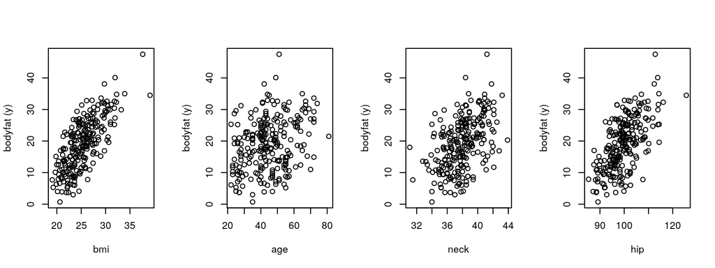

For a good predictive model we need to dive into *multiple linear regression*. However, wer start with the simple case of *only one predictor variable*:

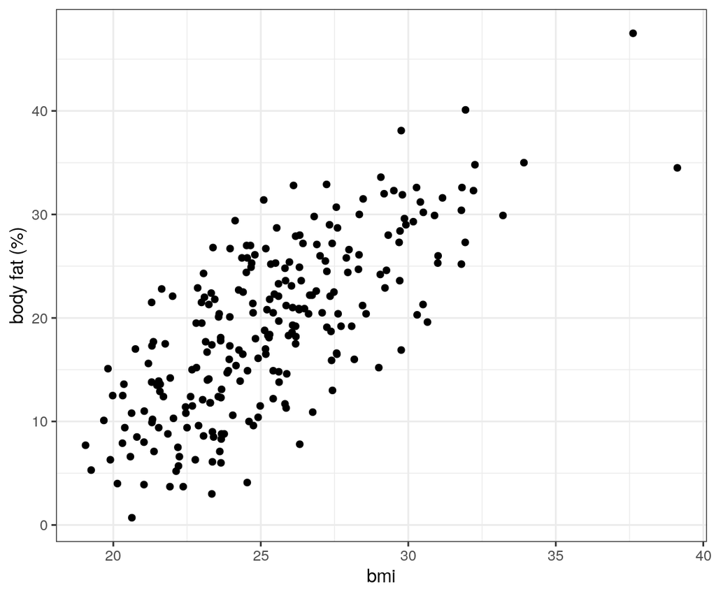

**Interesting questions**

1. How good is BMI as a predictor for body fat?
2. How strong is this relationship?
3. Is the relationship linear?
4. Are also other variables associated with `bodyfat`?
5. How well can we predict the bodyfat of a person?

# Simple Linear Regression

- One quantitative response $Y$ is modelled
- from *one covariate* $x$ (=simple),
- and the relationship between $Y$ and $x$ is assumed to be *linear*.

If the relation between $Y$ and $x$ is perfectly linear, all instances of $(x,Y)$, given by $(x_i,y_i)$, $i= 1,\ldots, n$, lie on a straight line and fulfill
$$y_i = \beta_0 + \beta_1 x_i\ .$$

But which is the “true” or “best” line, if the relationship is not exact?

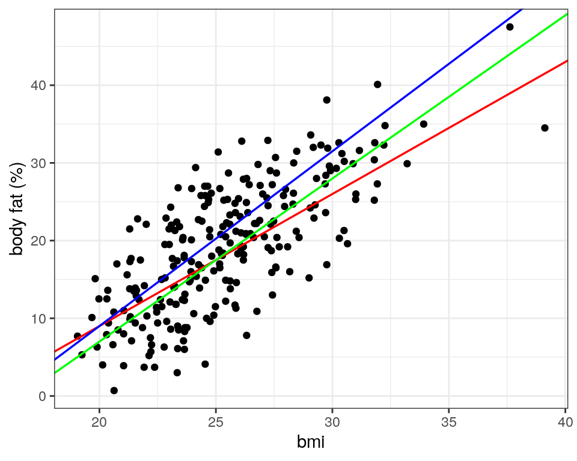

**Task:** Estimate the intercept and slope parameters (by “eye”) and write it down (we will look at the “best” answer later).

$\rightarrow$ Mentimeter

It is obvious that

- the linear relationship does not describe the data perfectly.
- another realization of the data (other 243 males) would lead to a slightly different picture.

$\Rightarrow$ We need a **model** that describes the relationship between BMI and bodyfat.

## The simple linear regression model

In the linear regression model the dependent variable $Y$ is related to the independent variable $x$ as

$$Y = \beta_0 + \beta_1 x + \varepsilon \ , \qquad \varepsilon \sim N(0,\sigma^2) \ .$$

In this formulation $Y$ is a random variable $Y \sim N(\beta_0 + \beta_1 x, \sigma^2$) where
$$Y \quad= \quad \underbrace{\text{ expected value }}_{\mathsf{E}(Y) = \beta_0 + \beta_1 x} \quad + \quad \underbrace{\text{ error}}_{\varepsilon} \ .$$

Note:

- The model for $Y$ given $x$ has : $\beta_0$ (intercept), $\beta_1$ (slope coefficient) and $\sigma^2$ .
- $x$ is the / / variable.
- $Y$ is the / / variable.

## Modeling assumptions

The central assumption in linear regression is that for any pairs ($x_i,Y_i$), the error $\varepsilon_i \sim N(0,\sigma^2)$. This implies

1. The expected value of $\varepsilon_i$ is 0: $\mathsf{E}(\varepsilon_i)=0$.
2. All $\varepsilon_i$ have the same variance: $\mathsf{Var}(\varepsilon_i)=\sigma^2$.
3. All $\varepsilon_i$ are normally distributed.
4. $\varepsilon$ is independent of any variable, observation number etc.
5. $\varepsilon_1, \varepsilon_2, \ldots, \varepsilon_n$ are independent of each other.

## Visualization of the regression assumptions

The assumptions about the linear regression model lie in the error term
$$\varepsilon \sim N(0,\sigma^2) \ .$$

Note: The true regression line goes through $\mathsf{E}(Y)$.

## Parameter estimation (“model fitting”)

In a regression analysis, the task is to estimate the **regression coefficients** $\beta_0$, $\beta_1$ and the **residual variance** $\sigma^2$ for a given set of $(x,y)$ data.

- **Problem:** For more than two points $(x_i,y_i)$, $i=1,\ldots, n$, there is generally no perfectly fitting line.
- **Aim**: We want to find the parameters $(a,b)$ of the best fitting line $Y = a + b x$.
- **Idea:** Minimize the deviations between the data points $(x_i,y_i)$ and the regression line.

But what are we actually going to minimize?

## Least squares

Remember the **Least Squared Method**. Graphically, we are minimizing the sum of the squared distances over all points:

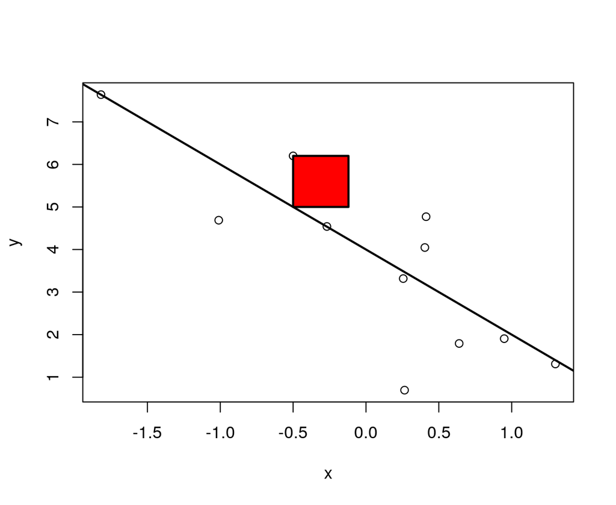

- Mathematically, $a$ and $b$ are estimated such that the sum of (residual sum of squares)

$$\text{RSS} = \sum_{i=1}^n e_i^2 \ , \qquad \text{where} \quad e_i = y_i - (a + b x_i)$$

is being minimized.

- The respective “best” estimates are called $\hat{\beta_0}$ and $\hat{\beta_1}$.
- We can predict the value of the response for a (new) observation of the covariate at $x$.
  $$\hat{y} = \hat{\beta}_0 + \hat{\beta_1}x.$$
- The $i$-th *residual* of the model is the difference between the $i$-th *observed* response value and the $i$-th *predicted* value, and is written as:
  $$e_i = Y_i - \hat{y}_i.$$
- We may regard the residuals as *predictions* (not estimates) of the error terms $\varepsilon_i$.

(The error terms are random variables and can not be estimated - they can be predicted. It is only for parameters that we speak about estimates.)

## Least squares estimators:

Using $n$ observed independent data points
$$(x_1,y_1), (x_2,y_2), \ldots, (x_n,y_n)\ ,$$

the least squares estiamtes for simple linear regression are given as

$$\begin{equation}
\hat{\beta}_0 = \bar{y}-\hat{\beta}_1 \bar{x}
\end{equation}$$
and
$$\begin{equation}
\hat{\beta}_1 = \frac{\sum_{i=1}^n(x_i-\bar{x})(y_i-\bar{y})}{\sum_{i=1}^n(x_i-\bar{x})^2} = \frac{\mathsf{Cov}(\boldsymbol{x},\boldsymbol{y})}{\mathsf{Var}(\boldsymbol{x})}\ ,
\end{equation}$$

where $\bar{y} = \frac{1}{n} \sum_{i=1}^n y_i$ and $\bar{x} = \frac{1}{n}\sum_{i=1}^n x_i$ are the sample means.

This is something you should have proven in your previous statistics classes; if you forgot how to get there, please check again, e.g. in chapter 11 of the book by Walepole et al. (2012), see [here](https://github.com/stefaniemuff/statlearning/blob/master/literature/Walepole_book.pdf).

## Do-it-yourself “by hand”

Go to the Shiny gallery and try to ``estimate’’ the correct parameters.

You can do this here:

https://gallery.shinyapps.io/simple_regression/

### Example continued: Body fat

Assume a linear relationship between the % bodyfat (`bodyfat`) and the BMI (`bmi`), we can get the LS estimates using R as follows:

$~$

```r
r.bodyfat = lm(bodyfat ~ bmi, data = d.bodyfat)
```

$~$

The estimates (and more information) can be obtained as follows:

$~$

```r
summary(r.bodyfat)$coef
```

```
##               Estimate Std. Error   t value     Pr(>|t|)
## (Intercept) -26.984368  2.7689004 -9.745518 3.921511e-19
## bmi           1.818778  0.1083411 16.787522 2.063854e-42
```

We see that the model fits the data quite well. It captures the essence. It looks that a linear relationship between `bodyfat` and `bmi` is a good approximation.

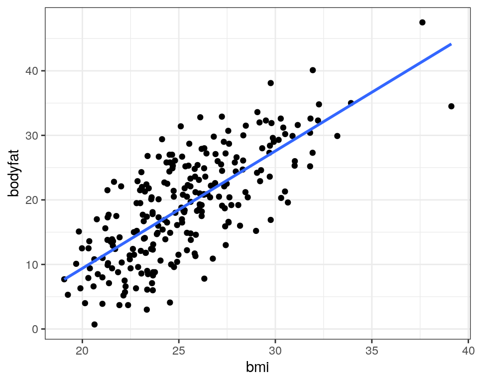

**Questions:**

- The blue line gives the estimated model. Explain what the line means in practice. Is this result plausible?
- Compare the estimates for $\beta_0$ and $\beta_1$ to the estimates you gave at the beginning - were you close?
- How does this relate to the *true* (population) model?
- **What could the regression line look like if another set of 243 males were used for estimation?**

### Uncertainty in the estimates $\hat\beta_0$ and $\hat\beta_1$

Note: $\hat\beta_0$ and $\hat\beta_1$ are themselves and as such contain !

Let us look again at the regression output, this time only for the coefficients. The second column shows the standard error of the estimate:

```r
summary(r.bodyfat)$coef
```

```
##               Estimate Std. Error   t value     Pr(>|t|)
## (Intercept) -26.984368  2.7689004 -9.745518 3.921511e-19
## bmi           1.818778  0.1083411 16.787522 2.063854e-42
```

$~$

$\rightarrow$ The logical next question is: what is the distribution of the estimates?

## Distribution of the estimators for $\hat\beta_0$ and $\hat\beta_1$

To obtain an intuition, we generate data points according to model

$$y_i = 4 - 2x_i + \varepsilon_i \ , \quad \varepsilon_i\sim N(0,0.5^2).$$
In each round, we estimate the parameters and store them:

```r
set.seed(1)
niter <- 1000
pars <- matrix(NA, nrow = niter, ncol = 2)
for (ii in 1:niter) {
    x <- rnorm(100)
    y <- 4 - 2 * x + rnorm(100, 0, sd = 0.5)
    pars[ii, ] <- lm(y ~ x)$coef
}
```

Doing it 1000 times, we obtain the following distributions for $\hat\beta_0$ and $\hat\beta_1$:

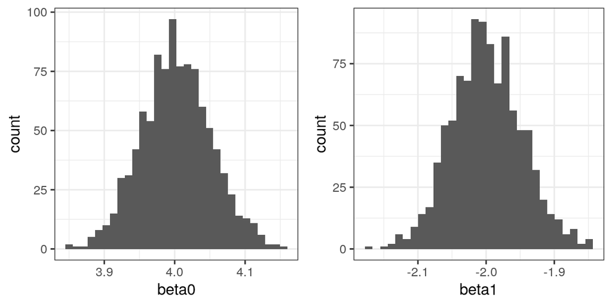

## Accuracy of the parameter estimates

- The standard errors of the estimates are given by the following formulas:
  $$\mathsf{Var}(\hat{\beta}_0)=\text{SE}(\hat{\beta}_0)^2 = \sigma^2 \Big [ \frac{1}{n} + \frac{\bar{x}^2}{\sum_{i=1}^n (x_i -\bar{x})^2} \Big]$$
  and
  $$\mathsf{Var}(\hat{\beta}_1)=\text{SE}(\hat{\beta}_1)^2 = \frac{\sigma^2}{\sum_{i=1}^n (x_i-\bar{x})^2}.$$
- $\mathsf{Cov}(\hat{\beta_0},\hat{\beta_1})$ is in general different from zero.

$~$ $~$

**Note**: We will *derive a general version* of these formulas for multiple linear regression, because without matrix notation this is very cumbersome.

Under the assumption that $\varepsilon \sim N(0,\sigma^2)$, and assuming $\hat\beta_0$ and $\hat\beta_1$ are estimated as in formulas (1) and (2), we have in addition that

$$\hat\beta_0 \sim N(\beta_0,{\sigma^{2}_{\beta_0}}) \quad \text{and} \quad \hat\beta_1 \sim N(\beta_1,{\sigma^{2}_{\beta_1}}) \ .$$

**Again**: We will derive this in the multiple linear regression version in more generality (see recommended exercise 3).

## Design issue with data collection

Recall that

$$\text{SE}(\hat{\beta}_1)^2 = \frac{\sigma^2}{\sum_{i=1}^n (x_i-\bar{x})^2} \ ,$$

thus for a given $\sigma^2$, the standard error is only dependent on the *design* of the $x_i$’s!

- Would we like the $\text{SE}(\hat{\beta}_1)^2$ large or small? Why?
- If it is possible for us to choose the $x_i$’s, which strategy should we use to choose them?

## Residual standard error (RSE)

- **Problem**: $\sigma$ is usually not known, but needs to be estimated.
- Remember: The residual sum of squares is $\text{RSS}=\sum_{i=1}^n (y_i-\hat{\beta}_0-\hat{\beta_1}x_{i})^2$.
- An estimate of $\sigma$, the residual standard error, RSE, is given by
  $$\hat\sigma = \text{RSE} =\sqrt{\frac{1}{n-2} \text{RSS}} = \sqrt{\frac{1}{n-2}\sum_{i=1}^n (y_i -\hat{y}_i)^2} \ .$$
- So actually we have

$$\hat{\text{SE}}(\hat{\beta}_1)^2 = \frac{{\hat\sigma}^2}{\sum_{i=1}^n (x_i-\bar{x})^2} \ ,$$
but we usually just write ${\text{SE}}(\hat{\beta}_1)^2$ (without the extra hat).

The estimated standard errors can be seen using the `summary()` function:

$~$

```r
summary(r.bodyfat)$coef
```

```
##               Estimate Std. Error   t value     Pr(>|t|)
## (Intercept) -26.984368  2.7689004 -9.745518 3.921511e-19
## bmi           1.818778  0.1083411 16.787522 2.063854e-42
```

# Testing and Confidence Intervals

After the regression parameters and their uncertainties have been estimated, there are typically two fundamental questions:

1. **“Are the parameters compatible with some specific value?”** Typically, the question is whether the slope $\beta_1$ might be 0 or not, that is: “Is $x$ an informative predictor or not?”

$\rightarrow$ This leads to a **statistical test**.

2. “Which values of the parameters are compatible with the data?”

$\rightarrow$ This leads us to determine **confidence intervals**.

Let’s first go back to the output from the bodyfat example:

```r
summary(r.bodyfat)$coef
```

```
##               Estimate Std. Error   t value     Pr(>|t|)
## (Intercept) -26.984368  2.7689004 -9.745518 3.921511e-19
## bmi           1.818778  0.1083411 16.787522 2.063854e-42
```

Besides the estimate and the standard error (which we discussed before), there is a `t value` and a probability `Pr(>|t|` that we need to understand.

How do these things help us to answer the two questions above?

## Testing the effect of a covariate

$~$

Remember: in a statistical test you first need to specify the . Here, typically, the null hypothesis is

$$H_0: \quad \beta_1 = 0 \ .$$

In words: $H_0$ = ``There is no relationship between $X$ and $Y$.’’

Here, the is given by $~$

$$H_A: \quad \beta_1 \neq 0$$

Remember: To carry out a statistical test, we need a *test statistic*. This is some type of **summary statistic** that follows a known distribution under $H_0$. For our purpose, we use the so-called **$T$-statistic**

$$\begin{equation*}
T=\frac{\hat\beta_1 }{SE(\hat\beta_1)}\ .
\end{equation*}$$

*Note*: If you want to test against another value than $\beta_1=0$, the formula is

$$\begin{equation*}
T=\frac{\hat\beta_1 - c}{SE(\hat\beta_1)} \ .
\end{equation*}$$

## Distribution of parameter estimators

We will *derive a general version* for multiple linear regression!

$~$

Brief recap: Under $H_0$, $T$ has a $t$-distribution with $n-2$ degrees of freedom ($n=$ number of data points; compare to Chapter 8.6 in Walepole et al. (2012)).

### Hypothesis tests for bodyfat example

$~$

So let’s again go back to the bodyfat regression output:

```r
summary(r.bodyfat)$coef
```

```
##               Estimate Std. Error   t value     Pr(>|t|)
## (Intercept) -26.984368  2.7689004 -9.745518 3.921511e-19
## bmi           1.818778  0.1083411 16.787522 2.063854e-42
```

**Q**: Check how the `Estimate`, `Std. Error` and `t value` relate.

$~$

- The last column contains the *$p$-values* of the tests with $H_0$: $\beta_0=0$ and $\beta_1=0$, respectively.
- The $p$-value for `bmi` is very small ($p<0.0001$). **What does this mean?**

### Cautionary notes regarding $p$-values:

$~$

- The (mis)use of $p$-values is heavily under critique in the scientific world!
- Simple yes/no decisions do often stand on very wiggly scientific ground.

$~$

We will discuss this a bit in the final module 12. The topic is connected to good/bad research practice, problems with ``reproducibility’’ and scientific progress in general. See e.g. here:

- The $p$-value statement by ASA: https://amstat.tandfonline.com/doi/full/10.1080/00031305.2016.1154108#.Xh16iuExnhM
- Ideas to redefine what ``statistical significane’’ means: https://www.nature.com/articles/s41562-017-0189-z
- Recently written with some co-authors: https://www.cell.com/trends/ecology-evolution/fulltext/S0169-5347(21)00284-6

## Confidence intervals

- Confidence intervals (CIs) are a much more informative way to report results than $p$-values!
- The $t$-distribution can be used to create confidence intervals for the regression parameters. The lower and upper limits of a 95% confidence interval for $\beta_j$ are
  $$\hat{\beta}_j \pm t_{(1-\alpha/2),n-2} \cdot\text{SE} (\hat{\beta}_j) \quad j=0, 1.$$
- Interpretation of this confidence interval:
  - There is a 95% probability that the interval will contain the *true* value of $\beta_j$.
  - **It is the range of parameter estimates that are *compatible with the data*** .

We can directly ask R to give us the CIs:

```r
confint(r.bodyfat, level = c(0.95))
```

```
##                  2.5 %     97.5 %
## (Intercept) -32.438703 -21.530032
## bmi           1.605362   2.032195
```

**Interpretation:**

For an increase in the bmi by one index point, roughly $\ldots$ percentage points more bodyfat are expected, and all true values for $\beta_1$ between $\ldots$ and $\ldots$ are $\ldots$.

# Model accuracy

Measured by

1. The **residual standard error (RSE)**, which provides an **absolute measure** of *lack of fit* (see above).
2. The **coefficient of determination $R^2$**, which measures the proportion of $y$’s variance explained by the model (between 0 and 1), is a **relative measure** of *lack of fit*:

$$R^2 = \frac{\text{TSS}-\text{RSS}}{\text{TSS}}= 1-\frac{\text{RSS}}{\text{TSS}}=1-\frac{\sum_{i=1}^n(y_i-\hat{y}_i)^2}{\sum_{i=1}^n(y_i-\bar{y}_i)^2},$$

where
$$\text{TSS} = \sum_{i=1}^n (y_i - \bar{y})^2$$
is the *total sum of squares*, a measure for the total variability in $Y$.

### $R^2$ in simple linear regression

**Note**: In simple linear regression, $R^2$ is the squared correlation between the independent and the dependent variable.

Verify this by comparing $R^2$ from the bodyfat output to the squared correlation between the two variables:

$~$

```r
summary(r.bodyfat)$r.squared
```

```
## [1] 0.5390391
```

```r
cor(d.bodyfat$bodyfat, d.bodyfat$bmi)^2
```

```
## [1] 0.5390391
```

# Multiple Linear Regression

Remember that the bodyfat dataset contained much more information than only bmi and bodyfat:

- `bodyfat`: % of body fat.
- `age`: age of the person.
- `weight`: body weighth.
- `height`: body height.
- `bmi`: bmi.
- `abdomen`: circumference of abdomen.
- `hip`: circumference of hip.

## Model

$~$

We assume
$$\begin{equation}
Y = \beta_0 + \beta_{1} X_1 + \beta_2 X_2 + ... + \beta_p X_p + \varepsilon \ ,
\end{equation}$$

where $X_j$ is the $j$th predictor and $\beta_j$ the respective regression coeffficient.

$~$

Assume we have $n$ sampling units $(x_{1i},\ldots,x_{pi}, y_i)$, $1\leq i \leq n$, such that each represents an instance of equation (3), we can use the data matrix

$${\bf{X}} = \left[\begin{matrix} 1 & x_{11} & ... & x_{1p} \\
1 & x_{21} & ... & x_{2p} \\
\vdots & ... & ... & \vdots \\
1 & x_{n1} & ... & x_{np} \\
\end{matrix}\right]$$

to write the model in matrix form:
$${\bf Y}={\bf {X}} \boldsymbol{\beta}+{\boldsymbol{\varepsilon}}$$

## Notation

$~$

- ${\bf Y}: (n \times 1)$ vector of responses (e.g., bodyfat).
- ${\bf X}: (n \times (p+1))$ design matrix, and ${\boldsymbol x}_i^T$ is a $(p+1)$-dimensional row vector for observation $i$.
- ${\boldsymbol \beta}: ((p+1) \times 1)$ vector of regression parameters $(\beta_0,\beta_1,\ldots,\beta_p)^\top$.
- ${\boldsymbol \varepsilon}: (n\times 1)$ vector of random errors.
- We assume that pairs $({\boldsymbol x}_i^T,y_i)$ $(i=1,...,n)$ are measured from *independent* sampling units.

$~$

Remark: other books, including the book in TMA4267 and TMA4315 define $p$ to include the intercept. This may lead to some confusion about $p$ or $p+1$ in formulas…

## Classical linear model

$~$

$${\bf Y=X \boldsymbol\beta}+{\boldsymbol \varepsilon}$$

Assumptions:

1. $\mathsf{E}(\boldsymbol{\varepsilon})=\boldsymbol{0}$.
2. $\mathsf{Cov}(\boldsymbol{\varepsilon})=\mathsf{E}(\boldsymbol{\varepsilon}\boldsymbol{\varepsilon}^T)=\sigma^2\boldsymbol{I}$.
3. The design matrix has full rank, $\text{rank}({\bf X})=p+1$. (We assume $n>>(p+1)$.)

The classical *normal* linear regression model is obtained if additionally

4. $\boldsymbol\varepsilon\sim N_n({\boldsymbol 0},\sigma^2 {\bf I})$ holds. Here $N_n$ denotes the $n$-dimensional multivarate normal distribution.

## The bodyfat example for two predictors

$~$

We are looking at the regression model

$$\begin{equation*}
Y = \beta_0 + \beta_{1} X_1 + \beta_2 X_2 + \varepsilon \ ,
\end{equation*}$$

with bodyfat as the response ($Y$) and `bmi` and `age` as $X_1$ and $X_2$.

$~$

The regression

```r
r.bodyfat = lm(bodyfat ~ bmi + age, data = d.bodyfat)
```

$~$

The :

```r
head(model.matrix(r.bodyfat))
```

```
##   (Intercept)   bmi age
## 1           1 23.65  23
## 2           1 23.36  22
## 3           1 24.69  22
## 4           1 24.91  26
## 5           1 25.54  24
## 6           1 26.48  24
```

## Distribution of the response vector

$~$

Assume that

$${\bf Y=X \boldsymbol\beta}+{\boldsymbol \varepsilon} \ , \quad \boldsymbol\varepsilon\sim N_n({\bf 0},\sigma^2 {\bf I}) \ .$$

**Q:**

- What is the expected value $\mathsf{E}(\bf Y)$?
- The covariance matrix $\mathsf{Cov}(\bf Y)$ given $\bf{X}$?
- Thus what is the distribution of $\bf Y$?

**A**:
$${\bf Y} \sim N_{n}({\bf X} {\boldsymbol\beta},\sigma^2 {\bf I})$$

## Parameter estimation for $\boldsymbol{\beta}$

$~$

In multiple linear regression, the parameter vector $\boldsymbol\beta$ is estimated with and . These two methods give the same estimator when we assume the normal linear regression model.

$~$

With least suqres, we minimize the RSS for a multiple linear regression model:
$$\begin{aligned} \text{RSS} &=\sum_{i=1}^n (y_i - \hat y_i)^2 = \sum_{i=1}^n (y_i - \hat \beta_0 - \hat \beta_1 x_{i1} - \hat \beta_2 x_{i2} -...-\hat \beta_p x_{ip} )^2 \\
&= \sum_{i=1}^n (y_i-{\boldsymbol x}_i^T \hat{\boldsymbol\beta})^2=({\bf Y}-{\bf X}\hat{\boldsymbol{\beta}})^T({\bf Y}-{\bf X}\hat{\boldsymbol{\beta}})\end{aligned}$$
The estimator is found by solving the system of $(p+1)$ equations

$$\frac{\partial \text{RSS}}{\partial \boldsymbol \beta}={\bf 0} \ .$$

$\rightarrow$ Derivation on the board.

Summing up:

is given like
$$\hat{\boldsymbol\beta}=({\bf X}^T{\bf X})^{-1} {\bf X}^T {\bf Y} \ .$$

## Example continued

```r
r.bodyfat3 <- lm(bodyfat ~ bmi + age + neck + hip + abdomen, data = d.bodyfat)
summary(r.bodyfat3)
```

```
##
## Call:
## lm(formula = bodyfat ~ bmi + age + neck + hip + abdomen, data = d.bodyfat)
##
## Residuals:
##     Min      1Q  Median      3Q     Max
## -9.3727 -3.1884 -0.1559  3.1003 12.7613
##
## Coefficients:
##             Estimate Std. Error t value Pr(>|t|)
## (Intercept) -7.74965    7.29830  -1.062  0.28939
## bmi          0.42647    0.23133   1.844  0.06649 .
## age          0.01457    0.02783   0.524  0.60100
## neck        -0.80206    0.19097  -4.200 3.78e-05 ***
## hip         -0.31764    0.10751  -2.954  0.00345 **
## abdomen      0.83909    0.08418   9.968  < 2e-16 ***
## ---
## Signif. codes:  0 '***' 0.001 '**' 0.01 '*' 0.05 '.' 0.1 ' ' 1
##
## Residual standard error: 4.392 on 237 degrees of freedom
## Multiple R-squared:  0.7185, Adjusted R-squared:  0.7126
## F-statistic:   121 on 5 and 237 DF,  p-value: < 2.2e-16
```

Reproduce the values under `Estimate` by calculating without the use of `lm`.

$~$

```r
X = model.matrix(r.bodyfat3)
Y = d.bodyfat$bodyfat
betahat = solve(t(X) %*% X) %*% t(X) %*% Y
print(betahat)
```

```
##                    [,1]
## (Intercept) -7.74964673
## bmi          0.42647368
## age          0.01457356
## neck        -0.80206081
## hip         -0.31764315
## abdomen      0.83909391
```

## Distribution of the regression parameter estimator

Given
$$\hat{\boldsymbol\beta}=({\bf X}^T{\bf X})^{-1} {\bf X}^T {\bf Y} \ ,$$

**what are**

- The mean $\mathsf{E}(\hat{\boldsymbol\beta})$?
- The covariance matrix $\mathsf{Cov}(\hat{\boldsymbol\beta})$?
- The distribution of $\hat{\boldsymbol\beta}$?

**Hint:** Use that

- $\hat{\boldsymbol\beta}={\bf C}{\bf Y}$ with ${\bf C}=({\bf X}^T{\bf X})^{-1} {\bf X}^T$.
- ${\bf Y} \sim N_{n}({\bf X} {\boldsymbol\beta},\sigma^2 {\bf I})$.

**Answers:**

See Problem 2 of recommended exercise 3 (and the respective solutions) to derive that

$$\hat{\boldsymbol\beta}\sim N_{p+1}(\boldsymbol{\beta},\underbrace{\sigma^2({\bf X}^T{\bf X})^{-1}}_{\text{covariance matrix}}) \ .$$

### The covariance matrix of $\boldsymbol{\hat\beta}$ in R

$~$

The covariance matrix for the $\boldsymbol{\hat\beta}$ can be obtained as follows:

$~$

```r
vcov(r.bodyfat3)
```

```
##             (Intercept)           bmi           age          neck          hip
## (Intercept) 53.26521684  0.6774596810 -0.0780438125 -0.7219656479 -0.548205733
## bmi          0.67745968  0.0535131152  0.0005729015 -0.0120408637 -0.005804073
## age         -0.07804381  0.0005729015  0.0007745054 -0.0003432518  0.001523951
## neck        -0.72196565 -0.0120408637 -0.0003432518  0.0364680351 -0.002715930
## hip         -0.54820573 -0.0058040729  0.0015239515 -0.0027159299  0.011558850
## abdomen      0.16457979 -0.0110809165 -0.0011917596 -0.0007706161 -0.004570722
##                   abdomen
## (Intercept)  0.1645797895
## bmi         -0.0110809165
## age         -0.0011917596
## neck        -0.0007706161
## hip         -0.0045707222
## abdomen      0.0070861066
```

How does this compare to simple linear regression? Not so easy to see a connection!

$$\hat{\beta}_0 = \bar{Y}-\hat{\beta}_1 \bar{x} \text{ and } \hat{\beta}_1 = \frac{\sum_{i=1}^n(x_i-\bar{x})(Y_i-\bar{Y})}{\sum_{i=1}^n(x_i-\bar{x})^2},$$

$$\hat{\boldsymbol\beta}=({\bf X}^T{\bf X})^{-1} {\bf X}^T {\bf Y} \ .$$

$~$

**Exercise:** Verify the connection using $\boldsymbol\beta=(\beta_0,\beta_1)^\top$ and ${\bf X}= \left[\begin{matrix} 1 & x_{11} \\ 1 & x_{21} \\ 1 & \vdots \\ 1 & x_{n1} \\ \end{matrix}\right]$.

# Four important questions

1. Is at least one of the predictors $X_1, \ldots, X_p$ useful in predicting the response?
2. Do all the predictors help to explain $Y$, or is only a subset of predictors useful?
3. How well does the model fit the data?
4. Given a set of predictor variables, how accurate is our prediction?

## 1. Relationship between predictors and response?

$~$

Question is whether we could as well omit all predictor variables at the same time, that is

To answer this, we need the $F$-statistic

$$F = \frac{(\text{TSS}-\text{RSS})/p}{\text{RSS}/(n-p-1)} \sim F_{p,(n-p-1)}\ ,$$

where total sum of squares $\text{TSS}=\sum_i(y_i-\bar{y})^2$, and residual sum of squares $\text{RSS}=\sum_i(y_i-\hat{y}_i)^2$. Under the Normal regression assumptions, $F$ follows an $F_{p,(n-p-1)}$ distribution (see Walepole et al. (2012), Chapter 8.7).

- If $H_0$ is true, $F$ is expected to be $\approx 1$.
- Otherwise, we expect that the numerator is larger than the denominator (because the regression then explains a lot of variation) and thus $F$ is greater than 1. For an observed value $f_0$, the $p$-value is given as
  $$p =P(F_{p,n-p-1}> f_0) \ .$$

Checking the $F$-value in the `R` output:

$~$

```r
summary(r.bodyfat)
```

```
##
## Call:
## lm(formula = bodyfat ~ bmi + age, data = d.bodyfat)
##
## Residuals:
##      Min       1Q   Median       3Q      Max
## -12.0415  -3.8725  -0.1237   3.9193  12.6599
##
## Coefficients:
##              Estimate Std. Error t value Pr(>|t|)
## (Intercept) -31.25451    2.78973 -11.203  < 2e-16 ***
## bmi           1.75257    0.10449  16.773  < 2e-16 ***
## age           0.13268    0.02732   4.857 2.15e-06 ***
## ---
## Signif. codes:  0 '***' 0.001 '**' 0.01 '*' 0.05 '.' 0.1 ' ' 1
##
## Residual standard error: 5.329 on 240 degrees of freedom
## Multiple R-squared:  0.5803, Adjusted R-squared:  0.5768
## F-statistic: 165.9 on 2 and 240 DF,  p-value: < 2.2e-16
```

$~$

Conclusion?

## More complex hypotheses

$~$

Sometimes we don’t want to test if all $\beta$’s are zero at the same time, but only a subset $1,\ldots , q$:

$$H_0: \beta_1=\beta_2=\cdots= \beta_q =0$$
$$H_1: \text{at least one different from zero}.$$

Again, the $F$-test can be used, but now $F$ is calculated like

$$F=\frac{(\text{RSS$_0$-RSS})/(q)}{\text{RSS}/(n-p-1)} \sim F_{q,n-p-1} \ ,$$

where

- Large model: RSS with $p+1$ regression parameters
- Small model: RSS$_0$ with $p+1-q$ regression parameters

## Example in R

- **Question:** Do `weight` and `height` explain something of `bodyfat`, on top of the variables `bmi` and `age`?
- Fit both models and use the `anova()` function to carry out the $F$-test:

$~$

```r
r.bodyfat.small = lm(bodyfat ~ bmi + age, data = d.bodyfat)
r.bodyfat.large = lm(bodyfat ~ bmi + age + weight + height, data = d.bodyfat)
anova(r.bodyfat.small, r.bodyfat.large)
```

```
## Analysis of Variance Table
##
## Model 1: bodyfat ~ bmi + age
## Model 2: bodyfat ~ bmi + age + weight + height
##   Res.Df    RSS Df Sum of Sq      F Pr(>F)
## 1    240 6816.2
## 2    238 6702.9  2    113.28 2.0112 0.1361
```

## Inference about a single predictor $\beta_j$

$~$

A special case is

$$H_0: \beta_j=0 \; \text{ vs. } \; H_1: \beta_j\neq 0$$

- Nothing new: We did it for simple linear regression!
- This makes sense: it is known that (or you can try to show it yourself)
  $$F_{1,n-p-1} = t^2_{n-p-1} \ ,$$
  thus we can use a $T$-statistic with $(n-p-1)$ degrees of freedom to get the $p$-value.

Going back again:

$~$

```r
summary(r.bodyfat)$coef
```

```
##                Estimate Std. Error    t value     Pr(>|t|)
## (Intercept) -31.2545057 2.78973238 -11.203406 1.039096e-23
## bmi           1.7525705 0.10448723  16.773060 2.600646e-42
## age           0.1326767 0.02731582   4.857137 2.149482e-06
```

$~$

**However**:

Only checking the individual $p$-values is dangerous. **Why?**

## Inference about $\beta_j$: confidence interval

$~$

- Using that
  $$T_j=\frac{\hat{\beta}_j}{\text{SE}(\hat\beta_j)}\sim t_{n-p-1} \ ,$$
  we can create confidence intervals for $\beta_j$ in the same manner as we did for simple linear regression (see slide 41). For example, when using the typical confidence level $\alpha=0.05$ we have

```r
confint(r.bodyfat)
```

```
##                   2.5 %      97.5 %
## (Intercept) -36.7499929 -25.7590185
## bmi           1.5467413   1.9583996
## age           0.0788673   0.1864861
```

## 2. Deciding on important variables

$~$

Overarching question:

$~$

But:

- Not clear what *best* means $\rightarrow$ we need an objective criterion, like AIC, BIC, Mallows $C_p$, adjusted $R^2$.
- There are usually **many** possible models. For $p$ predictors, we can build $2^p$ different models.
- **Cautionary note**: Model selection can also lead to biased parameters estimates.

$~$

$\rightarrow$ This topic is the focus of Module 6.

## 3. Model Fit

$~$

We can again look at the two measures from simple linear regression:

$~$

- An absolute measure of lack of fit is again given by the estimate of $\sigma$, the residual standard error (RSE)

$$\hat\sigma = \text{RSE}= \sqrt{ \frac{ \text{RSS}}{n-p-1}} \ .$$

- $R^2$ is again the fraction of variance explained (no change from simple linear regression)
  $$R^2 = \frac{\text{TSS}-\text{RSS}}{\text{TSS}}= 1-\frac{\text{RSS}}{\text{TSS}}=1-\frac{\sum_{i=1}^n(y_i-\hat{y}_i)^2}{\sum_{i=1}^n(y_i-\bar{y}_i)^2} \ .$$
  Simply speaking: “The higher $R^2$, the better.”

### However: Caveat with $R^2$

$~$

Let us look at the $R^2$s from the three bodyfat models

model 1: $y\sim bmi$

model 2: $y\sim bmi + age$

model 3: $y\sim bmi + age + neck + hip + abdomen$

$~$

```r
summary(r.bodyfatM1)$r.squared
```

```
## [1] 0.5390391
```

```r
summary(r.bodyfatM2)$r.squared
```

```
## [1] 0.5802956
```

```r
summary(r.bodyfatM3)$r.squared
```

```
## [1] 0.718497
```

$~$

The models explain 54%, 58% and 72% of the total variability of $y$.

It thus *seems* that larger models are ``better’’. However, $R^2$ does always increase when new variables are included, but this does not mean that the model is more reasonable.

## Adjusted $R^2$

$~$

When the sample size $n$ is small with respect to the number of variables $m$ included in the model, an *adjusted* $R^2$ gives a better (“fairer”) estimation of the actual variability that is explained by the covariates:

$$\begin{equation*}
R^2_a = 1-(1-R^2 )\frac{n-1}{n-p-1}
\end{equation*}$$

$~$

$R^2_a$ **penalizes for adding more variables** if they do not really improve the model!

$~$

$\rightarrow$ $R_a$ may decrease when a new variable is added.

## Model fit – in a broader sense

$~$

We will look at model validation / model checking later.

## 4. Predictions: Two questions

$~$

1. **Which other regression lines are compatible with the observed data?**

$\rightarrow$ We can use $\hat\beta_0, \ldots , \hat\beta_p$ to estimate the *least squares plane*
$$\hat{Y} = \hat\beta_0 + \hat\beta_1 X_1 + \ldots + \hat\beta_p X_p$$
as an approximation of $f(X) = \beta_0 + \beta_1 X_1 + \ldots + \beta_p X_p .$ This leads to the .

2. **Where do future observations with a given $x$ coordinate lie?**

$\rightarrow$ Even if we could predict $\hat{Y}=f(X)$, the *true* value $Y = f(X) + \varepsilon$ varies around $\hat{Y}$. We can compute a for new observations $Y$.

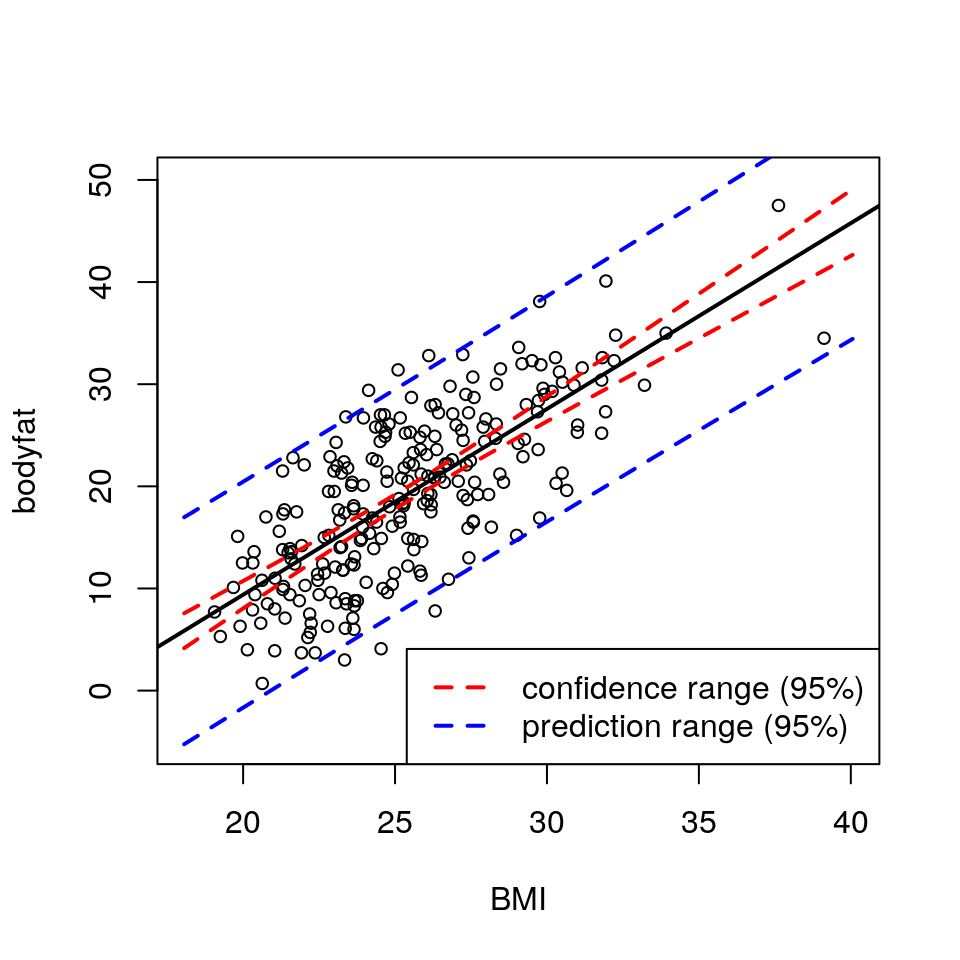

- Plotting the confidence and prediction intervals around all predicted values $\hat Y_0$ one obtains the **confidence range** or **confidence band** for the expected values of $Y$.

Note: The prediction range is much broader than the confidence range. Why?

### Calculation of the confidence intervals/range

$~$

- Given a realization of $X_1, \ldots ,X_p$, say $x_1^{(0)}, \ldots x_p^{(0)}$. The question is:  
  **Where does $\hat y_0 = \hat\beta_0 + \hat\beta_1 x_1^{(0)} + \ldots \hat\beta_p x_p^{(0)}$ lie with a certain confidence (i.e., 95%)?**
- This question is not trivial, because $\hat\beta_0, \ldots \hat\beta_p$ are estimates from the data and contain uncertainty.

$~$

- For the confidence range, only the uncertainty in the estimates $\hat\beta_0, \ldots \hat\beta_p$ matters.

### Calculation of the prediction intervals/range

$~$

- Given a new value of $X_1, \ldots, X_p$, say $x_1^{(0)}, \ldots x_p^{(0)}$. The question is:  
  **Where does a future observation $y_0$ lie with a certain confidence (i.e., 95%)?**
- To answer this question, we have to sum uncertainty over two components:
  1. the $\hat y_0 = \hat\beta_0 + \hat\beta_1 x_1^{(0)} + \ldots \hat\beta_p x_p^{(0)}$ (due to uncertainty in $\hat{\boldsymbol\beta}$).
  2. the $\varepsilon_0 \sim N(0,\sigma^2)$.
- The *prediction intervals and range are always wider than the confidence intervals and range*.
- Confidence and prediction intervals for given data points can be found in R using `predict` on an `lm` object (make sure that `newdata` is a `data.frame` with the same names as the original data).

$~$

```r
fit = lm(bodyfat ~ bmi + age + abdomen, data = d.bodyfat)
newobs = d.bodyfat[1, ]
```

```r
predict(fit, newdata = newobs, interval = "confidence", type = "response")
```

```
##        fit      lwr      upr
## 1 13.17595 11.99122 14.36069
```

```r
predict(fit, newdata = newobs, interval = "prediction", type = "response")
```

```
##        fit      lwr     upr
## 1 13.17595 3.951613 22.4003
```

Finally, we need to keep in mind that the model we work with is only an *approximation of the reality*. In fact,

(Box 1979)

# Extensions of the linear model

Extensions that make the linear model very powerful:

$~$

- Binary covariates (e.g., male/female, smoker/non-smoker)
- Categorical covariates (e.g., black/white/green)?
- Interaction terms
- Non-linear terms

## Binary predictors

$~$

So far, the covariates $X$ were always continuous.

In reality, there are no restrictions assumed with respect to the $X$ variables.

One very frequent data type are **binary** variables, that is, variables that can only attain values 0 or 1.

If the binary variable $x$ is the only variable in the model $Y_i = \beta_0 + \beta_1 x_i + \varepsilon_i$, the model has only two predicted outcomes (plus error):

$$\begin{equation*}
Y_i = \left\{
\begin{array}{ll}
\beta_0 + \varepsilon_i \quad &\text{if } x_i=0 \ , \\
\beta_0 + \beta_1 + \varepsilon_i \quad &\text{if } x_i =1 \ .\\
\end{array}
\right .
\end{equation*}$$

**Example**: Credit card data analysis in Section 3.3.1 in the ISLR book.

## Qualitative predictors with more than 2 levels

$~$

More generally, a covariate may indicate a **category**, for instance the species of an animal or a plant. This type of covariate is called a **factor**. The trick: convert a factor variable $X$ with $k$ levels (for instance 3 species) into $k$ dummy variables $X_j$ with

$$\begin{equation*}
x_{ij} = \left\{
\begin{array} {ll}
1, & \text{if the $i$th observation belongs to group $j$}.\\
0, & \text{otherwise.}
\end{array}\right.
\end{equation*}$$

Each of the covariates $x_1,\ldots, x_k$ can then be included as a binary variable in the model
$$\begin{equation*}
y_i = \beta_0 + \beta_1 x_1 + \ldots + \beta_k x_k + \varepsilon_i \ .
\end{equation*}$$

However: this model is .

**Solution:** One of the $k$ categories must be selected as a *reference category* and is *not included in the model*. Typically: the first category is the reference, thus $\beta_1=0$.

The model thus discriminates between the factor levels, such that (assuming $\beta_1=0$)

$$\begin{equation*}
y_i = \left\{
\begin{array}{ll}
\beta_0 + \varepsilon, & \text{if $x_{i1}=1$ }\\
\beta_0 + \beta_2 + \varepsilon, & \text{if $x_{i2}=1$ }\\
...\\
\beta_0 + \beta_k + \varepsilon, & \text{if $x_{ik}=1$ } \ .
\end{array}\right.
\end{equation*}$$

## !Important to remember!

$\rightarrow$ The *degrees of freedom* of the fitted model are therefore reduced by $k-1$.

## Example

$~$

We are now using the `Credit` dataset from the `ISLR` library.

$~$

```r
library(ISLR)
data(Credit)
head(Credit)
```

```
##   ID  Income Limit Rating Cards Age Education Gender Student Married Ethnicity
## 1  1  14.891  3606    283     2  34        11   Male      No     Yes Caucasian
## 2  2 106.025  6645    483     3  82        15 Female     Yes     Yes     Asian
## 3  3 104.593  7075    514     4  71        11   Male      No      No     Asian
## 4  4 148.924  9504    681     3  36        11 Female      No      No     Asian
## 5  5  55.882  4897    357     2  68        16   Male      No     Yes Caucasian
## 6  6  80.180  8047    569     4  77        10   Male      No      No Caucasian
##   Balance
## 1     333
## 2     903
## 3     580
## 4     964
## 5     331
## 6    1151
```

$~$

Question: Do the Balances differ for different Ethnicities (Caucasian/Asian/Afro-American)?

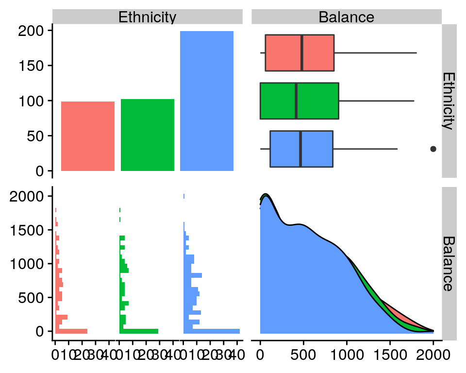

```r
library(GGally)
ggpairs(Credit[, c("Ethnicity", "Balance")], aes(colour = Ethnicity))
```

In R, a factor covariate can be used in the same way as a continuous predictor:

$~$

```r
r.lm <- lm(Balance ~ Ethnicity, data = Credit)
summary(r.lm)$coef
```

```
##                     Estimate Std. Error    t value     Pr(>|t|)
## (Intercept)        531.00000   46.31868 11.4640565 1.774117e-26
## EthnicityAsian     -18.68627   65.02107 -0.2873880 7.739652e-01
## EthnicityCaucasian -12.50251   56.68104 -0.2205766 8.255355e-01
```

$~$

Interpretation? Do the ethnicities really differ? Check also the $F$-test in the last line of the summary output.

$~$

$$\begin{equation*}
\hat{y}_i = \left\{
\begin{array}{ll}
\qquad \qquad\qquad \qquad\qquad & \text{if $i$ is Asian}\\[2mm]
\qquad \qquad\qquad \qquad\qquad & \text{if $i$ is Caucasian}\\[2mm]
\qquad \qquad\qquad \qquad\qquad & \text{if $i$ is Afro-American}\\
\end{array}\right.
\end{equation*}$$

## Sidenote: The “reference category”

In the above example we do not see a result for the `EthnicityAfrican American`. Why?

- `African American` is chosen to be the reference category.
- The results for `EthnicityAsian` and `EthnicityCaucasian` are **differences** with respect to the reference cateogry.
- R chooses the reference category in alphabetic order! This is sometimes not a relevant category.
- You can change the reference category:

$~$

```r
library(dplyr)
Credit <- mutate(Credit, Ethnicity = relevel(Ethnicity, ref = "Caucasian"))
r.lm <- lm(Balance ~ Ethnicity, data = Credit)
summary(r.lm)$coef
```

```
##                             Estimate Std. Error    t value     Pr(>|t|)
## (Intercept)               518.497487   32.66986 15.8708211 2.824537e-44
## EthnicityAfrican American  12.502513   56.68104  0.2205766 8.255355e-01
## EthnicityAsian             -6.183762   56.12165 -0.1101850 9.123184e-01
```

Note: The differences are now with respect to the Caucasian category – the model is however exactly the same!

## Testing for a categorical predictor

**Question**: Is a qualitative predictor needed in the model?

For a predictor with more than two levels (like Ethnicity above), the Null Hypothesis is whether

$$\beta_1 = \ldots = \beta_{k-1}=0$$
at the same time.

$\rightarrow$ We again need the $F$-test, as **always when we test for more than one $\beta_j=0$ *simultaneously***!

In R, this is done by the `anova()` function:

```r
anova(r.lm)
```

```
## Analysis of Variance Table
##
## Response: Balance
##            Df   Sum Sq Mean Sq F value Pr(>F)
## Ethnicity   2    18454    9227  0.0434 0.9575
## Residuals 397 84321458  212397
```

## Interactions: Removing the additivity assumption

We again look at the `Credit` dataset. We want to model the `Balance` as a function of `Income` and wheter the person is a student or not.

The model is given as
$$\text{Balance}_i = \beta_0 + \beta_1 \cdot \text{Income}_i + \beta_2 \cdot \text{Student}_i + \varepsilon_i \ ,$$
where `Student` is a binary variable. Thus we have a model that looks like
$$\begin{equation*}
\text{Balance}_i = \left\{
\begin{array}{ll}
\beta_0 + \beta_2 + \beta_1 \cdot \text{Income}_i + \varepsilon_i \ , & \text{if $i$ is a student,}\\
\beta_0 + \qquad \; \beta_1 \cdot \text{Income}_i + \varepsilon_i & \text{otherwise.}
\end{array}
\right.
\end{equation*}$$

In R, we simply add `Student` to the model:

```r
r.lm <- lm(Balance ~ Income + Student, Credit)
```

$~$

**Caveat:** This model assumes that students and non-students have the same slope for `Income`. Realistic?

Let’s look at the graphs:

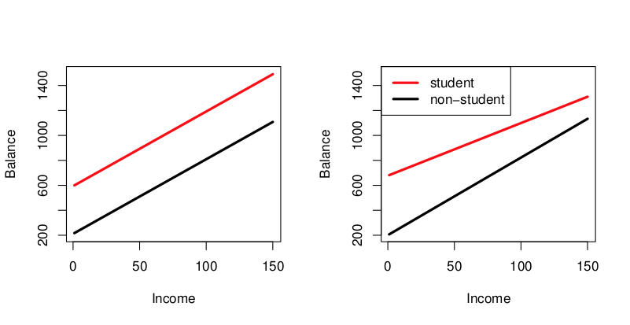

ISLR Figure 3.7

$\rightarrow$ We want a model that allows for different slopes!

## Interaction terms

We formulate a new model that includes the interaction term $(\text{Income}\cdot \text{Student})$:

$$\text{Balance}_i = \beta_0 + \beta_1 \cdot \text{Income}_i + \beta_2 \cdot \text{Student}_i + \beta_3 \cdot \text{Income}_i \cdot \text{Student}_i + \varepsilon_i \ ,$$

Thus we have a model that allows for different intercept *and* slope for the two groups:

$$\begin{equation*}
\text{Balance}_i = \left\{
\begin{array}{ll}
\beta_0 + \beta_2 + (\beta_1 + \beta_3) \cdot \text{Income}_i + \varepsilon_i \ , & \text{if $i$ is a student,}\\
\beta_0 + \qquad \; \beta_1 \cdot \text{Income}_i + \varepsilon_i & \text{otherwise.}
\end{array}
\right.
\end{equation*}$$

In R, this is again quite simple:

```r
r.lm <- lm(Balance ~ Income * Student, Credit)
summary(r.lm)$coef
```

```
##                     Estimate  Std. Error   t value     Pr(>|t|)
## (Intercept)       200.623153  33.6983706  5.953497 5.789658e-09
## Income              6.218169   0.5920936 10.502003 6.340684e-23
## StudentYes        476.675843 104.3512235  4.567995 6.586095e-06
## Income:StudentYes  -1.999151   1.7312511 -1.154743 2.488919e-01
```

$~$

**Interpretation:**

We allow the model to depend on the binary variable `Student`, such that

For a student: $\hat{y} =$ 200.6 + 476.7 + (6.2 + -2.0) $\cdot$ Income

For a non-Student: $\hat{y} =$ 200.6 + (6.2) $\cdot$ Income

**Question:** Is the interaction relevant here?

## The hierarchical principle

$~$

If we include an interaction in a model, we should also include the main effects, even if the $p$-values associated with the coefficients of the main effects are large (see p.89 in ISLR book).

## More interactions

We can include interactions also between

- two continuous variables.
- a categorical variable with more than 2 levels and a continuous variable.

$\rightarrow$ See problem 1 in recommended exercises 3 (important)!

## Non-linear terms

**Linear regression is even more powerful!**

- We have seen that it is possible to include continuous, binary or factorial covariates in a regression model.
- Even of covariates can be included in (almost) any form. For instance the square of a variable $X^2$
  $$\begin{equation*}
  y_i = \beta_0 + \beta_1 x_i + \beta_2 x_i^2 + \varepsilon_i \ ,
  \end{equation*}$$
  which leads to a **quadratic** or **polynomial** regression (if higher order terms are used).
- Other common transformations are:
  - $\log$
  - $\sqrt{..}$
  - $\sin$, $\cos$,

How can a regression be a ??

**Note**:

The word *linear* refers to the , and not on a linear relationship between $Y$ and $X_1, \ldots , X_p$!

**Question**: When would we need such a regression? Well, sometimes the world is not linear. In particular, if

- there is a theoretical/biological/medical reason to believe in a non-linear relationship, or
- the residual analysis indicates that there are non-linear associations in the data.

$\rightarrow$ In the later modules, we will discuss other more advanced non-linear approaches for addressing this issue.

# Challenges - for model fit

$~$

1. Non-linearity of data
2. Correlation of error terms
3. Non-constant variance of error terms
4. Non-Normality of error terms
5. Outliers
6. High leverage points
7. Collinearity

### Recap of modelling assumptions in linear regression

$~$

To make valid inference from our model, we must check if our model assumptions are fulfilled!

$~$

The assumption in linear regression is that the residuals follow a $N(0,\sigma^2)$ distribution, implying that :

$~$

1. The expected value of $\varepsilon_i$ is 0: $\mathsf{E}(\varepsilon_i)=0$.
2. All $\varepsilon_i$ have the same variance: $\mathsf{Var}(\varepsilon_i)=\sigma^2$.
3. The $\varepsilon_i$ are normally distributed.
4. The $\varepsilon_i$ are independent of each other.

## Model checking tool I: Tukey-Anscombe diagram

$~$

The diagram plots the residuals against the fitted values. For the bodyfat data it looks like this:

$~$

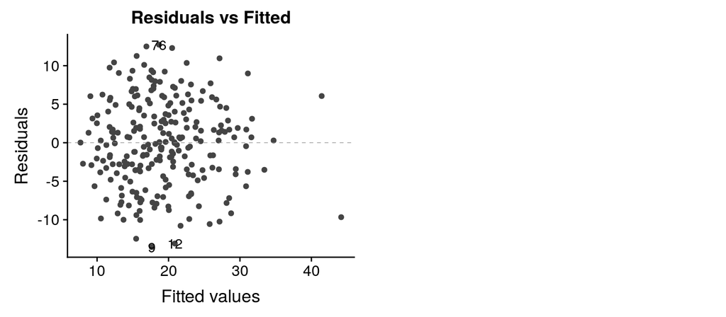

$~$

This plot is ideal to check if assumptions 1. and 2. (and partially 4.) are met. Here, this seems fine.

## Model checking tool II: The QQ-diagram

$~$

To check assumption 3., the quantiles of the observed distribution are plotted against the quantiles of the respective theoretical (normal) distribution:

$~$

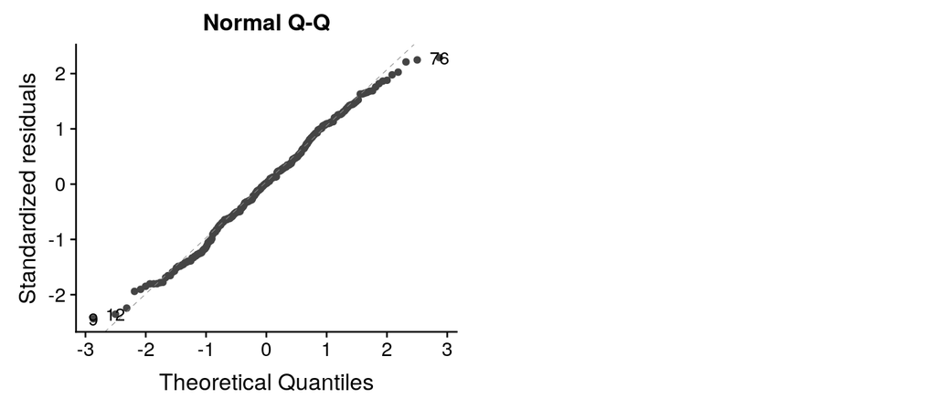

$~$

If the points lie approximately on a straight line, the data is fairly normally distributed. This is often ``tested’’ by eye, and needs some experience.

## Model checking tool III: The scale-location plot

$~$

The scale-location plot is particularly suited to check the assumption of equal variances (homoscedasticity; assumption 2.).

$~$

The idea is to plot the square root of the (standardized) residuals $\sqrt{|\tilde{r}_i|}$ against the fitted values $\hat{y_i}$. There should be *no trend*:

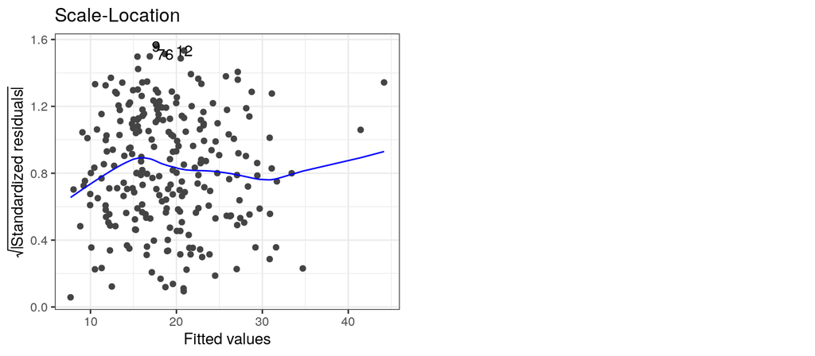

## Model checking tool IV: The leverage plot

$~$

- Mainly useful to determine outliers.

$~$

- To understand the leverage plot, we need to introduce the idea of the **leverage**.

$~$

- In simple regression, the leverage of individual $i$ is defined as

$$\begin{equation}
H_{ii} = \frac{1}{n} + \frac{(x_i-\overline{x})^2}{\sum_{i'}(x_{i'}-\overline{x})^2} \ .
\end{equation}$$

**Q:** When are leverages expected to be large/small?

$~$

**Illustration**: Data points with $x_i$ values far from the mean have a stronger leverage effect than when $x_i\approx \overline{x}$:

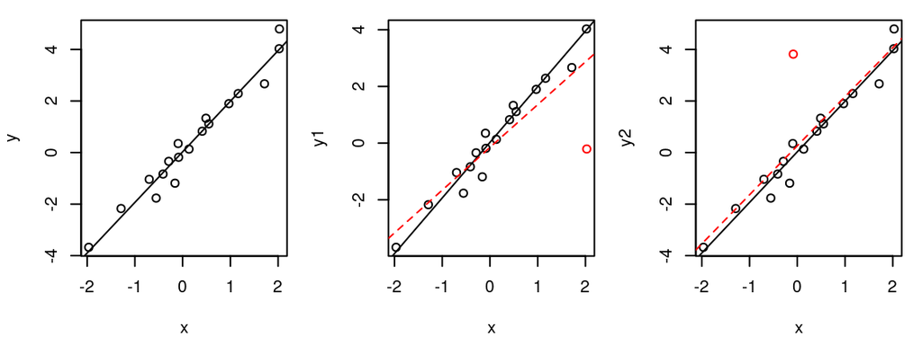

The outlier in the middle plot ``pulls’’ the regression line in its direction and biases the slope.

$~$

to do it manually!

In the leverage plot, (standardized) residuals $\tilde{r_i}$ are plotted against the leverage $H_{ii}$ (still for the bodyfat):

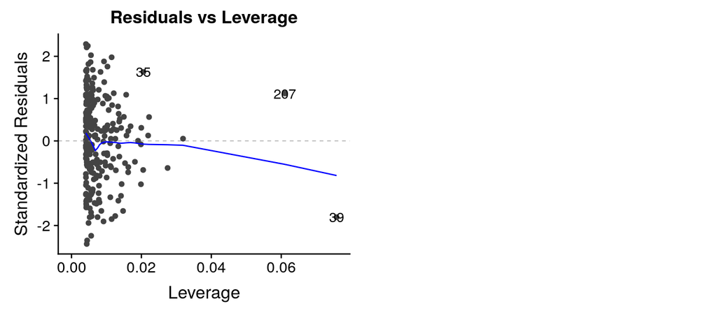

**Critical ranges** are the top and bottom right corners! Why?

### Leverages in multiple regression

- Leverage is defined as the diagonal elements of the so-called *hat matrix* $\mathbf{H}$, i.e., the leverage of the $i$-th data point is $H_{ii}$ on the diagonal of $\mathbf{H = X(X^TX)^{-1}X^T}$.
- Exercise: Verify that formula (4) comes out in the special case of simple linear regression.
- A large leverage indicates that the observation ($i$) has a large influence on the estimation results, and that the covariate values (${\boldsymbol x}_i$) are unusual.

### Different types of residuals?

$~$

It can be shown that the vector of residuals, ${\bf e}=(e_1,e_2,\ldots,e_n)$ have a normal (singular) distribution with

- $\mathsf{E}({\bf e})={\bf 0}$
- $\mathsf{Cov}({\bf e})=\sigma^2({\bf I}-{\bf H})$,

where ${\bf H}={\bf X}({\bf X}^T{\bf X})^{-1}{\bf X}^T$.

$~$

This means that the residuals (possibly) have different variance, and may also be correlated.

$~$

**Q:** Why is that a problem?

**A**:

- To check the model assumptions we want to look at the distribution of the error terms $\varepsilon_i$, to check that our errors are independent, homoscedastic (same variance for each observation), and not dependent on our covariates.
- However, we only have the residuals $e_i$, the “predictions” for $\epsilon_i$.
- It would have been great if the $e_i$ have the same properties as $\epsilon_i$.

$\rightarrow$ To make the $e_i$ more “like $\epsilon_i$”, we use or .

**Standardized residuals:**

$$\tilde{r}_i=\frac{e_i}{\hat{\sigma}\sqrt{1-H_{ii}}}$$
where $H_{ii}$ is the $i$th diagonal element of the hat matrix ${\bf H}$.

In R you can get the standardized residuals from an `lm`-object (named `fit`) by `rstandard(fit)`.

**Studentized residuals:**

$$r^*_i=\frac{e_i}{\hat{\sigma}_{(i)}\sqrt{1-H_{ii}}}$$
where $\hat{\sigma}_{(i)}$ is the estimated error variance in a model with observation number $i$ omitted. It can be shown that it is possible to calculated the studentized residuals directly from the standardized residuals.

In R you can get the studentized residuals from an `lm`-object (named `fit`) by `rstudent(fit)`.

### Diagnostic plots in `R`

See exercises: We use `autoplot()` from the `ggfortify` package in R to plot the diagnostic plots.

### Collinearity

In brief, collinearity refers to the situation when two or more predictors are correlated, thus encode (partially) for the same information.

$~$

**Problems:**

- Reduces the accuracy of the estimated coefficients $\hat\beta_j$ (large SE!).
- Consequently, reduces power in finding effects ($p$-values become larger).

$~$

**Solutions:**

- Detect it by calculating the *variance inflation factor* (VIF).
- Remove the problematic variable.
- Or combine the collinear variables into a single new one.

$~$

**Todo:** Read in the course book p.99-102 (self-study).

# Further reading

- [Videoes on YouTube by the authors of ISL, Chapter 3](https://www.youtube.com/playlist?list=PL5-da3qGB5IBSSCPANhTgrw82ws7w_or9)

# References

Box, G. E. P. 1979. “Robustness in the Strategy of Scientific Model Building.” In *In Robustness in Statistics*, edited by R. L. Launer and G. N. Wilkinson, 201–36. New York: Academic Press.

James, Gareth, Daniela Witten, Trevor Hastie, and Robert Tibshirani. 2013. *An Introduction to Statistical Learning*. Vol. 112. Springer.

Walepole, R. E., R. H. Myers, S. L. Myers, and K. Ye. 2012. *Probability & Statistics for Engineers and Scientists*. 9th ed. Boston: Pearson Education Inc.